# Bruhn_A15_3

A15.21

14行目の結果は、かなりの回数の乗算および加算の後に得られるため、数値的な誤りを犯しやすい。重大な誤りが生じていないかを確認するために、14行目の値を取り、各セルのこれら一定せん断流の値を、セルが分離している場合にねじれをゼロにするものとみなす。次に、共通のウェブを介してセルを結合すると、ねじれに乱れが生じるが、これは繰り越し値によってゼロにされる。表の中のこのステップは「反復」と呼ばれ、15行目に示されている。次に、15行目の値を5行目の初期近似値 $q'$ （この値は16行目に繰り返される）に加えることで、17行目に $q$ の最終値を得る。17行目の値は実質的に14行目の値と同じ大きさであるため、重大な誤りは犯されていない。もし差が顕著であった場合は、2回目の、そして必要であればさらに多くの回数の反復を行うべきである。表中では、18、19、20行目に2回目の反復が示されており、20行目の結果は17行目と実質的に同じである。

この与えられた5セル梁のせん断中心の横方向の位置は、Fig. A15.50 におけるせん断流力系の重心と一致する。せん断中心を配置するための計算は、Fig. A15.50 の下に示されている。

### 問題1の解法2

解法1において、仮定された静的状態では、右端のウェブを除くすべての垂直ウェブを切断することが含まれていた。したがって、静的な梁の断面は開水路断面となり、結果として得られる静的せん断流は、最終的な真のせん断流の値とは明らかに大きく異なるものにならざるを得ない。なぜなら、ねじれのない曲げにおいて、ウェブは常に大きなせん断流を担うからである。この事実は、最終的な結果の所望の精度を得るために連続する修正が十分に小さくなる状態に達するまでに、Table A15.2 において比較的多くのステップが必要であったことによって示されている。したがって、ウェブ内の静的せん断流が最終値に非常により近くなり、連続近似手順における収束を早めるような静的状態を仮定することが論理的である。

そこで Fig. A15.51 では、静的状態を得るために、各セルの上部パネルが切断されていると仮定した。静的せん断流は現在、垂直ウェブに限定され、上部および下部のシートではゼロ値となる。Table A15.3 は連続近似を実行するための計算を示しており、これ以上の説明は不要であろう。5行目で最初の近似を行った後、Table A15.2 の解法1で必要とされた8サイクルと同じ精度を得るために、6、7、8行目では3回の繰り越しサイクルしか必要としなかったことに注目すべきである。Fig. A15.52 は、表の9行目の各セルの一定せん断流を Fig. A15.51 の静的せん断流に加えた、最終的なせん断流を示している。これらの値は、計算尺の精度の範囲内で、Fig. A15.50 に示された解法1の結果と一致する。Table A15.3 では反復ステップは示されていない。学生はこのようなチェックを行うことを習慣にすべきである。

## A15.13 例題2

**すべての材料が耐曲げ性に有効である場合。**

超音速翼の構造設計の一般的な傾向は、多数のセルと比較的厚い外板を使用することであり、したがって一般に、翼のすべての断面積材料は曲げ応力への抵抗に有効であり、そのためせん断流は梁セルの壁およびウェブに沿って強度が変化する。Fig. A15.53 は、示されているようなウェブおよび壁の厚さを持つ10セル梁を示している。梁のすべての材料が曲げに有効であると仮定する。ねじれを伴わない水平軸まわりの曲げに対するせん断流抵抗システムを決定する。このシステムの重心がせん断中心の位置を特定することになる。

Fig. A15.54 は、仮定された静的状態を示している。すなわち、各セルの上部シートパネルがその中間点で切断されていると仮定し、これによりこれらの点での静的せん断流 $q_s$ をゼロにしている。静的せん断流の値 $q_s$ は Fig. A15.54 に示されている。これらがどのように計算されたかを説明するために、計算例を以下に示す。

水平重心軸まわりの全断面の慣性モーメントは、

上部および下部外板の $I_x$

すべてのウェブの $I_x$

$$= (0.912 \times 5^3) / 12 = 9.5$$

$$\text{合計 } I_x = 87.5 \text{ in}^4$$

便宜上、この梁断面に作用する外力としてのせん断荷重 $V_z = 8750$ lb. を仮定する。

したがって、

$$q = -\frac{V_z}{I_x} \Sigma ZA = -\frac{8750}{87.5} \Sigma ZA = -100 \Sigma ZA$$

A15.22

ここで、セル(1)とセル(2)の半分を示す Fig. A15.55 のスケッチを考える。前述のように、上部セルパネルはそれらの中間点 (a) および (m) で切断されていると仮定されている。

### 解法 II

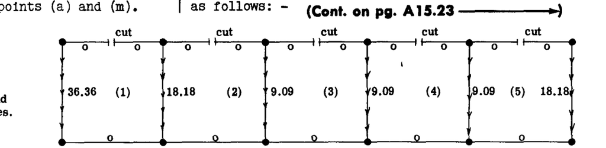

Fig. A15-51

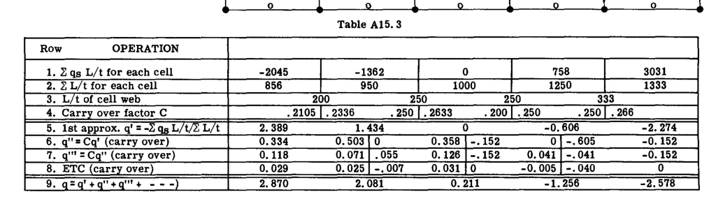

Table A15. 3

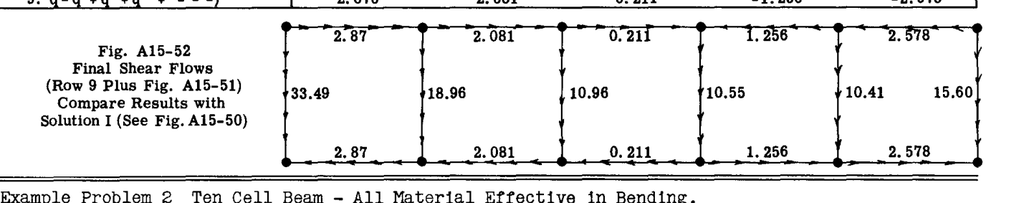

Fig. A15-52

### 例題 2 10セル梁 - すべての材料が曲げに有効である場合

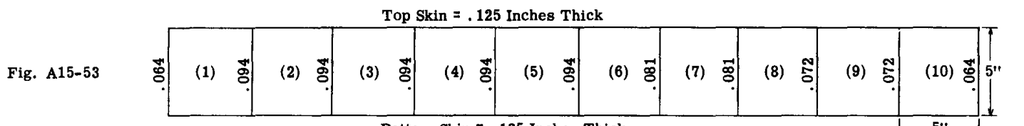

Fig. A15-53

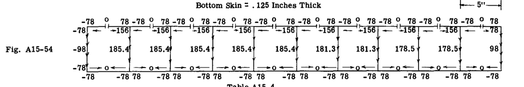

Fig. A15-54

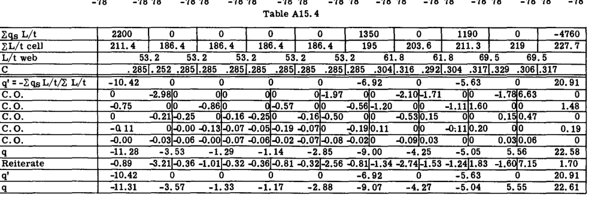

Table A15. 4

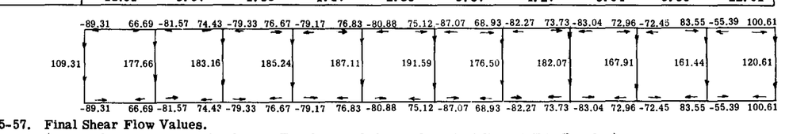

Fig. A15-57

A15.23

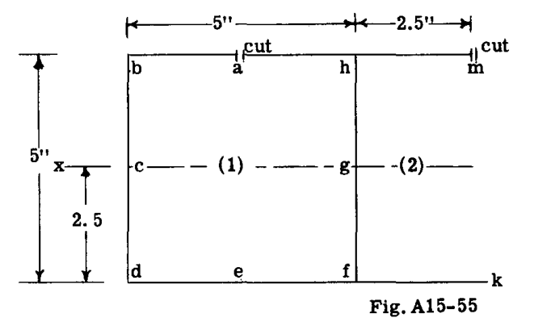

Fig. A15-55

$$q_a = 0$$

$$q_b = -100 \Sigma_a^b ZA = -100 \times 2.5 \times 2.5 \times 0.125 = -78 \text{ lb./in.}$$

$$q_c = q_b - 100 \Sigma_b^c ZA = -78 - 100 \times (1.25 \times 2.5 \times 0.064) = -78 - 20 = -98 \text{ lb./in.}$$

$$q_d = -98 - \Sigma_c^d ZA = -98 - 100 \times (-1.25) \times (2.5 \times 0.064) = -98 + 20 = -78$$

$$q_e = -78 - \Sigma_d^e ZA = -78 - 100 \times (-2.5) \times (2.5 \times 0.125) = -78 + 78 = 0$$

$$q_{fe} = 0 - \Sigma_e^f ZA = 0 - 100 \times (-2.5) \times (2.5 \times 0.125) = 78$$

点 (f) では、他に2つの接続するシートパネルがあるため、(f) における2つの接続シート内のせん断流を計算する際、この結合部を越えて進むことはできない。

したがって、点 (a) に戻り、時計回りに進む。

$$q_a = 0$$

$$q_{ha} = 0 + 100 \Sigma_a^h ZA = 0 + 100 \times (2.5 \times 2.5 \times 0.125) = 78 \text{ lb./in.}$$

$$q_m = 0$$

$$q_{hm} = 0 - 100 \Sigma_m^h ZA = -100 \times (2.5 \times 2.5 \times 0.125) = -78$$

現在、結合部 (h) では、各上部パネルに 78 の大きさのせん断流があるため、(h) における垂直ウェブのせん断流は、これら2つのせん断流の和、すなわち 156 に等しくなる。

7. へ進む。

$$q_g = q_{hg} + 100 \Sigma_h^g ZA = 156 + 100 \times (1.25 \times 2.5 \times 0.094) = 156 + 29.4 = 185.4 \text{ lb./in.}$$

$$q_{fg} = 185.4 + 100 \Sigma_g^f ZA = 185.4 + 100 \times (-1.25) \times (2.5 \times 0.094) = 156 \text{ lb./in.}$$

$$q_{fk} = q_{fg} - q_{fe} = -156 + 78 = -78$$

$$q_{kf} = -78 - 100 \Sigma_f^k ZA = -78 - 100 \times (-2.5) \times (2.5 \times 0.125) = -78 + 78 = 0$$

Fig. A15.56 は、これらの計算値のプロットを示している。矢印はせん断流の向きを示している。

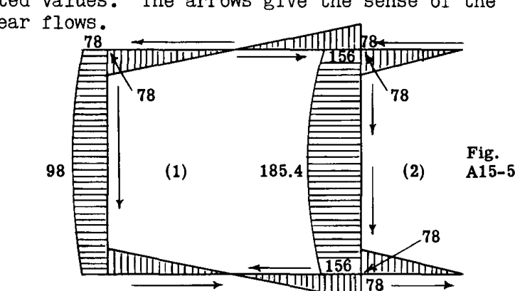

Fig. A15-56

Fig. A15.54 は、全10セルについて計算された静的せん断流の値を示している。値は、各シートパネルの端部および各シートパネルの中間点に記録されている。セル内の時計回りのせん断流は正のせん断流である。内部ウェブは2つの隣接するセルの一部であるため、垂直ウェブ上のせん断流の符号は、向きが正か負かを決定するために、左側のセルを基準とする。

$q_s$ として参照される静的せん断流を決定したので、Table A15.4 の操作を開始することができる。最初の水平行は、静的せん断流の下での各セルのねじれの計算を与え、これは各セルについて $\Sigma q_s \frac{L}{t}$ という項で相対的に測定される。

すべての材料が曲げに有効である場合、せん断流は各シートに沿って変化する。Fig. A15.56 は、セル(1)のシートパネルにおけるこの変化を示している。 $\Sigma q_s L/t$ という項は、各シート上のせん断流図の面積をシート厚さで割ったものに他ならない。説明のために、Fig. A15.56 のセル(1)を考える。

上部シートパネル：-

$$\Sigma q_s \frac{L}{t} = \frac{-(0 + 78)}{2} \frac{2.5}{0.125} + \frac{+(0 + 78)}{2} \frac{2.5}{0.125} = 0$$

A15.24

下部シートパネル：-

$$\Sigma q_s \frac{L}{t} = 0 \quad (\text{上部シートと同じ図})$$

左側垂直ウェブ：-

せん断流図を、高さ 78 の長方形と、高さ $98 - 78 = 20$ の放物線として処理すると、

$$\Sigma q_s \frac{L}{t} = \frac{-78 \times 5}{0.064} - \frac{(20 \times 5 \times 0.667)}{0.064} = -7142$$

セル(1)の右側ウェブについて、

せん断流図は同様に長方形と放物線で構成されている。

したがって、セル(1)全体について

$$\Sigma q_s \frac{L}{t} = -7142 + 9342 = 2200$$

これは、Table A15.4 のセル(1)の下の1行目の値である。他の9つのセルの結果も同様の方法で計算され、表の1行目に記録されている。Table A15.4 の残りの行で実行される手順は、例題1で詳細に説明したものと同じである。Table A15.4 では、5回目の繰り越しサイクルの後に達した値と、最下行または最終行の値が実質的に同じであるため、反復は1回しか実行されていない。表の最終行の一定せん断流の値を Fig. A15.54 の静的せん断流の値に加えると、Fig. A15.57 の最終せん断流の値が得られる。このせん断流パターンの合力は、 $Z$ 方向に下向きに作用する 8750 の力である。その位置は、せん断流力系の重心を通る。梁の左上隅からせん断流合力の作用線までの距離を $\bar{x}$ とする。

Fig. A15.54 のせん断流力系に、Table A15.4 の最終行に示されている各セルの一定閉鎖せん断流を加えたもののモーメントを取り、これを $8750\bar{x}$ と等置すると、以下を得る。

各ウェブ上の均一な静的せん断流によるもの：-

各ウェブ上の放物線状の静的せん断流によるもの：-

$$M = (29.4 \times 5 \times 0.667)(5 + 10 + 15 + 20 + 25) + 25.3 \times 5 \times 0.667(30 + 35) + 22.5 \times 5 \times 0.667(40 + 45) + 20 \times 5 \times 0.667 \times 50 = 22520$$

Table A15.4 の最終行にリストされている一定閉鎖せん断流によるもの：-

$$M = +(-11.31 - 3.57 - 1.33 - 1.17 - 2.88 - 9.07 - 4.27 - 5.04 + 5.55 + 22.61) \times 2 \times 25 = -520$$

Table A15.57 の最終的なせん断流の値を参照すると、最終結果は、2つの端部ウェブを除いて、仮定された静的せん断流と大きく異ならないことがわかる。もし静的状態を形成するために1つを除くすべてのウェブが切断されていると仮定していたら、Table A15.4 では最終結果の同じ精度を得るために数倍の繰り越しサイクルが必要であっただろう。